[figure not shown]

# Workshop FLAI Dominando Data Science

Baseado em: https://github.com/gitflai/Workshop-DDS  
Modificado por: Murilo Krominski https://github.com/MuriloKrominski

Canais da Flai: • Instagram: https://lnkd.in/eFdDvqA  
• YouTube: https://lnkd.in/e_cThD4  
• Twitter: https://lnkd.in/eEjQXPm  
• Site: https://www.flai.com.br/  
• Curso da Flai: https://lnkd.in/e_Ff_Zj  
*it's time to flai!*

## Requerimentos:

pandas==1.1.4  
pycaret==2.2  
streamlit==0.64.0

## Este notebook com a criação dos modelos utilizando o PyCaret:

https://murilokrominski.github.io/DDS-Flai_Inteligencia_Artificial-gitflai/

[Notebook: Medical Cost Personal Datasets](https://github.com/MuriloKrominski/DDS-Flai_Inteligencia_Artificial-gitflai/blob/main/Dados_de_Custos_Medicos.ipynb)

## Relatório1 (estático):

https://htmlpreview.github.io/?https://raw.githubusercontent.com/MuriloKrominski/DDS-Flai_Inteligencia_Artificial-gitflai/main/docs/Relatorio1.html

## Relatório1b (estático):

https://htmlpreview.github.io/?https://raw.githubusercontent.com/MuriloKrominski/DDS-Flai_Inteligencia_Artificial-gitflai/main/docs/Relatorio1b.html

## Relatório2 (estático):

https://htmlpreview.github.io/?https://raw.githubusercontent.com/MuriloKrominski/DDS-Flai_Inteligencia_Artificial-gitflai/main/docs/Relatorio2.html

## Aplicativo Web com o deploy dos modelos obtidos:

[Medical Cost Deploy Center](https://share.streamlit.io/gitflai/workshop-dds/main/medical.py)

# **Dados de Custos Médicos** | *Medical Cost Data*

Datasets provenientes da plataforma Kaggle e que podem ser acessados através de:  
https://www.kaggle.com/mirichoi0218/insurance  
https://github.com/stedy/Machine-Learning-with-R-datasets  
Medical Cost Personal Datasets  
Insurance Forecast by using Linear Regression

As variáveis desse dataset são:

- *age*: idade da pessoa.
- *sex*: gênero da pessoa.
- *bmi*: índice de massa corporal da pessoa.
- *children*: número de dependentes da pessoa.
- *smoker*: se a pessoa é fumante ou não
- *region*: região em que a pessoa mora.
- *charges*: custos médicos individuais cobrados pelo plano de saúde

O objetivo primário nesse dataset é fazer a previsão da variável custos. Fazer essa previsão é fundamental e de interesse de qualquer instituição que venda planos de saúde. Fazer essa precificação corretamente é fundamental para adquirir uma vantagem competitiva no mercado. Uma boa precificação garante que a instituição está operando dentro dos limites orçamentários e que cada pessoa pague o mais próximo do que seria uma parcela justa, de acordo com suas variáveis de entrada.

E os objetivos desse case são:

- Ilustrar os recursos do PyCaret
- Criar uma solução rápida e com boa performance.
- Explorar os contextos de regressão e classificação.
- Mostrar que é possível colocar uma nova ótica em conjuntos clássicos da literatura.
- Procedimento end-to-end de Machine Learning: dos dados ao deploy.

Um possíve objetivo secundário seria fazer um modelo para previsão da variável *fumante* para detectar possíveis fraudadores dessa variável. Como é uma variável que impacta significativamente no preço dos planos de saúde, algumas pessoas podem se ver tentadas a responderem que não são fumantes, quando na verdade são. Isso levaria a precificações incorretas e injustas. Para resolver isso, um modelo pode ser empregado e indicar a probabilidade de um indivídio estar comentendo fraude. Os indivíduos com maior probabilidade de fraude podem seguir para uma investigação mais detalhada do caso, de modo a evitar perdas maiores.

O outline desse case:

- Análise Exploratória de Dados (Rápida).
- Machine Learning com PyCaret | Objetivo primário: case de regressão.
- Machine Learning com PyCaret | Objetivo secundário: case de classificação.
- Considerações Finais.

## **Análise Exploratória de Dados (Rápida)**

### **Pandas**

```python
!pip install pandas
```

```python
import pandas as pd
```

```python
fonte = "https://raw.githubusercontent.com/stedy/Machine-Learning-with-R-datasets/master/insurance.csv"
dados = pd.read_csv(fonte, sep=",", low_memory="False")
```

```python
dados.head()
```

|  | age | sex | bmi | children | smoker | region | charges |
| --- | --- | --- | --- | --- | --- | --- | --- |
| 0 | 19 | female | 27.900 | 0 | yes | southwest | 16884.92400 |
| 1 | 18 | male | 33.770 | 1 | no | southeast | 1725.55230 |
| 2 | 28 | male | 33.000 | 3 | no | southeast | 4449.46200 |
| 3 | 33 | male | 22.705 | 0 | no | northwest | 21984.47061 |
| 4 | 32 | male | 28.880 | 0 | no | northwest | 3866.85520 |

### **Ligando o "modo Colab"**

```python
#Ligando modo Colab
#from pycaret.utils import enable_colab
#enable_colab()

#from pycaret.datasets import get_data
#dados = get_data('insurance')
```

### **EDA automática através do SweetViz**

```python
!pip install sweetviz
```

```python
import sweetviz
```

```python
eda = sweetviz.analyze(dados)
eda.show_html(filepath = 'C:/Users/mkrom/Desktop/DDS/Relatorio1.html')
```

```
Report C:/Users/mkrom/Desktop/DDS/Relatorio1.html was generated! NOTEBOOK/COLAB USERS: the web browser MAY not pop up, regardless, the report IS saved in your notebook/colab files.
```

```python
eda2 = sweetviz.compare_intra(dados, dados['smoker'] == 'yes', ['Fumante', 'Não Fumante'])
eda2.show_html(filepath = 'C:/Users/mkrom/Desktop/DDS/Relatorio2.html')
```

```
Report C:/Users/mkrom/Desktop/DDS/Relatorio2.html was generated! NOTEBOOK/COLAB USERS: the web browser MAY not pop up, regardless, the report IS saved in your notebook/colab files.
```

```python
import IPython
from IPython.display import IFrame
#IPython.display.HTML(filename='/content/Relatorio1.html')
#IPython.display.HTML(filename='/content/Relatorio2.html')

#IPython.display.HTML(filename='C:/Users/mkrom/Desktop/DDS/Relatorio1.html')
#IPython.display.HTML(filename='C:/Users/mkrom/Desktop/DDS/Relatorio2.html')
```

```python
IFrame(src = 'https://htmlpreview.github.io/?https://raw.githubusercontent.com/MuriloKrominski/DDS-Flai_Inteligencia_Artificial-gitflai/main/docs/Relatorio1.html',width=1000,height=600)
```

[interactive chart not shown]

```python
IFrame(src = 'https://htmlpreview.github.io/?https://raw.githubusercontent.com/MuriloKrominski/DDS-Flai_Inteligencia_Artificial-gitflai/main/docs/Relatorio2.html',width=1000,height=600)
```

[interactive chart not shown]

### **EDA automática através do ProfileReport**

```python
!pip install pandas-profiling
```

```python
from pandas_profiling import ProfileReport
```

```python
import warnings
warnings.filterwarnings('ignore')
```

```python
Relatorio1b = ProfileReport(dados, title='Relatorio1b', html={'style':{'full_width':True}})
```

```python
Relatorio1b.to_file(output_file="C:/Users/mkrom/Desktop/DDS/Relatorio1b")
```

```python
Relatorio1b.to_widgets()
```

### **EDA automática através do D-Tale**

```python
!pip install dtale
```

```python
import dtale
```

```python
Relatorio1c = dtale.show(dados)
Relatorio1c
```

[interactive chart not shown]

### **Acrescentando com um gráfico bastante pertinente:**

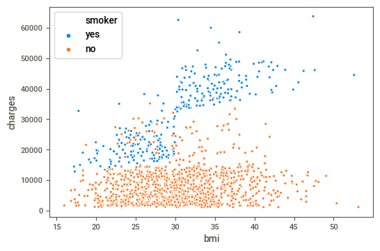

```python
import seaborn as sns
sns.scatterplot(x = 'bmi', y = 'charges', hue = 'smoker', data = dados);
```

## **Machine Learning com PyCaret | Objetivo primário: obter um bom modelo para previsão dos custos para melhor precificação de planos de saúde**

```python
!pip install pycaret
```

```python
from pycaret.regression import *
```

```python
# configurações de pré-processamento e validação nos modelos utilizados adiante.

regressao = setup(data = dados,
                  target = 'charges',
                  normalize = True,
                  combine_rare_levels = True,
                  remove_outliers = True,
                  session_id = 1)
```

|  | Description | Value |
| --- | --- | --- |
| 0 | session_id | 1 |
| 1 | Target | charges |
| 2 | Original Data | (1338, 7) |
| 3 | Missing Values | False |
| 4 | Numeric Features | 2 |
| 5 | Categorical Features | 4 |
| 6 | Ordinal Features | False |
| 7 | High Cardinality Features | False |
| 8 | High Cardinality Method | None |
| 9 | Transformed Train Set | (889, 12) |
| 10 | Transformed Test Set | (402, 12) |
| 11 | Shuffle Train-Test | True |
| 12 | Stratify Train-Test | False |
| 13 | Fold Generator | KFold |
| 14 | Fold Number | 10 |
| 15 | CPU Jobs | -1 |
| 16 | Use GPU | False |
| 17 | Log Experiment | False |
| 18 | Experiment Name | reg-default-name |
| 19 | USI | 27c9 |
| 20 | Imputation Type | simple |
| 21 | Iterative Imputation Iteration | None |
| 22 | Numeric Imputer | mean |
| 23 | Iterative Imputation Numeric Model | None |
| 24 | Categorical Imputer | constant |
| 25 | Iterative Imputation Categorical Model | None |
| 26 | Unknown Categoricals Handling | least_frequent |
| 27 | Normalize | True |
| 28 | Normalize Method | zscore |
| 29 | Transformation | False |
| 30 | Transformation Method | None |
| 31 | PCA | False |
| 32 | PCA Method | None |
| 33 | PCA Components | None |
| 34 | Ignore Low Variance | False |
| 35 | Combine Rare Levels | True |
| 36 | Rare Level Threshold | 0.100000 |
| 37 | Numeric Binning | False |
| 38 | Remove Outliers | True |
| 39 | Outliers Threshold | 0.050000 |
| 40 | Remove Multicollinearity | False |
| 41 | Multicollinearity Threshold | None |
| 42 | Clustering | False |
| 43 | Clustering Iteration | None |
| 44 | Polynomial Features | False |
| 45 | Polynomial Degree | None |
| 46 | Trignometry Features | False |
| 47 | Polynomial Threshold | None |
| 48 | Group Features | False |
| 49 | Feature Selection | False |
| 50 | Features Selection Threshold | None |
| 51 | Feature Interaction | False |
| 52 | Feature Ratio | False |
| 53 | Interaction Threshold | None |
| 54 | Transform Target | False |
| 55 | Transform Target Method | box-cox |

[output not shown]

### Criando um modelo incial básico, porém robusto, utilizando Random Forest.

```python
# para verificar o que cada parâmetro faz:
?setup
```

```python
models()
```

```
2020-11-19 14:31:24,473 - INFO     - gpu_param set to False
```

| ID | Name | Reference | Turbo |
| --- | --- | --- | --- |
| lr | Linear Regression | sklearn.linear_model._base.LinearRegression | True |
| lasso | Lasso Regression | sklearn.linear_model._coordinate_descent.Lasso | True |
| ridge | Ridge Regression | sklearn.linear_model._ridge.Ridge | True |
| en | Elastic Net | sklearn.linear_model._coordinate_descent.Elast... | True |
| lar | Least Angle Regression | sklearn.linear_model._least_angle.Lars | True |
| llar | Lasso Least Angle Regression | sklearn.linear_model._least_angle.LassoLars | True |
| omp | Orthogonal Matching Pursuit | sklearn.linear_model._omp.OrthogonalMatchingPu... | True |
| br | Bayesian Ridge | sklearn.linear_model._bayes.BayesianRidge | True |
| ard | Automatic Relevance Determination | sklearn.linear_model._bayes.ARDRegression | False |
| par | Passive Aggressive Regressor | sklearn.linear_model._passive_aggressive.Passi... | True |
| ransac | Random Sample Consensus | sklearn.linear_model._ransac.RANSACRegressor | False |
| tr | TheilSen Regressor | sklearn.linear_model._theil_sen.TheilSenRegressor | False |
| huber | Huber Regressor | sklearn.linear_model._huber.HuberRegressor | True |
| kr | Kernel Ridge | sklearn.kernel_ridge.KernelRidge | False |
| svm | Support Vector Regression | sklearn.svm._classes.SVR | False |
| knn | K Neighbors Regressor | sklearn.neighbors._regression.KNeighborsRegressor | True |
| dt | Decision Tree Regressor | sklearn.tree._classes.DecisionTreeRegressor | True |
| rf | Random Forest Regressor | sklearn.ensemble._forest.RandomForestRegressor | True |
| et | Extra Trees Regressor | sklearn.ensemble._forest.ExtraTreesRegressor | True |
| ada | AdaBoost Regressor | sklearn.ensemble._weight_boosting.AdaBoostRegr... | True |
| gbr | Gradient Boosting Regressor | sklearn.ensemble._gb.GradientBoostingRegressor | True |
| mlp | MLP Regressor | pycaret.internal.tunable.TunableMLPRegressor | False |
| xgboost | Extreme Gradient Boosting | xgboost.sklearn.XGBRegressor | True |
| lightgbm | Light Gradient Boosting Machine | lightgbm.sklearn.LGBMRegressor | True |
| catboost | CatBoost Regressor | catboost.core.CatBoostRegressor | True |

```python
floresta = create_model('rf')
```

|  | MAE | MSE | RMSE | R2 | RMSLE | MAPE |
| --- | --- | --- | --- | --- | --- | --- |
| 0 | 3047.8380 | 34295090.3239 | 5856.2010 | 0.7557 | 0.5792 | 0.2409 |
| 1 | 2919.1696 | 24453724.9724 | 4945.0708 | 0.8189 | 0.5461 | 0.3799 |
| 2 | 1874.0171 | 10946598.4006 | 3308.5644 | 0.8969 | 0.4306 | 0.4008 |
| 3 | 3473.4476 | 30126513.5600 | 5488.7625 | 0.7834 | 0.5380 | 0.4576 |
| 4 | 3141.1536 | 29144451.8455 | 5398.5602 | 0.7390 | 0.5267 | 0.3763 |
| 5 | 2475.1004 | 18452306.3242 | 4295.6148 | 0.8618 | 0.3905 | 0.2648 |
| 6 | 2886.9233 | 24403955.2648 | 4940.0360 | 0.8230 | 0.5089 | 0.3796 |
| 7 | 3041.4452 | 31713774.7250 | 5631.4984 | 0.7627 | 0.4791 | 0.3580 |
| 8 | 2624.5750 | 23753384.1731 | 4873.7444 | 0.8682 | 0.4940 | 0.2942 |
| 9 | 2924.7464 | 22207593.8501 | 4712.4934 | 0.8759 | 0.5479 | 0.5500 |
| Mean | 2840.8416 | 24949739.3440 | 4945.0546 | 0.8185 | 0.5041 | 0.3702 |
| SD | 412.8018 | 6521361.0089 | 704.3966 | 0.0533 | 0.0548 | 0.0865 |

```
2020-11-19 14:31:28,914 - INFO     - create_model_container: 1
2020-11-19 14:31:28,915 - INFO     - master_model_container: 1
2020-11-19 14:31:28,916 - INFO     - display_container: 1
2020-11-19 14:31:28,918 - INFO     - RandomForestRegressor(bootstrap=True, ccp_alpha=0.0, criterion='mse',
                      max_depth=None, max_features='auto', max_leaf_nodes=None,
                      max_samples=None, min_impurity_decrease=0.0,
                      min_impurity_split=None, min_samples_leaf=1,
                      min_samples_split=2, min_weight_fraction_leaf=0.0,
                      n_estimators=100, n_jobs=-1, oob_score=False,
                      random_state=1, verbose=0, warm_start=False)
2020-11-19 14:31:28,919 - INFO     - create_model() succesfully completed......................................
```

```python
# tunando a floresta através do método RandomSearch, isto é, explorando 20 alternativas diferentes de hiperparâmetros

floresta_tunada = tune_model(floresta, optimize = 'MAPE', n_iter = 20)
```

|  | MAE | MSE | RMSE | R2 | RMSLE | MAPE |
| --- | --- | --- | --- | --- | --- | --- |
| 0 | 2695.1455 | 33359674.3912 | 5775.7834 | 0.7623 | 0.5704 | 0.1857 |
| 1 | 2048.2134 | 21604042.9456 | 4648.0149 | 0.8400 | 0.4584 | 0.1519 |
| 2 | 741.5047 | 5266897.3514 | 2294.9722 | 0.9504 | 0.1833 | 0.1074 |
| 3 | 2289.3530 | 23898250.0342 | 4888.5836 | 0.8281 | 0.4241 | 0.1961 |
| 4 | 2158.7518 | 25896260.5448 | 5088.8369 | 0.7681 | 0.4466 | 0.1532 |
| 5 | 1964.9600 | 19085994.4535 | 4368.7520 | 0.8570 | 0.3877 | 0.1326 |
| 6 | 1694.1418 | 16366459.6347 | 4045.5481 | 0.8813 | 0.3570 | 0.1431 |
| 7 | 2360.4151 | 32697758.5478 | 5718.1954 | 0.7553 | 0.4302 | 0.1490 |
| 8 | 1992.9949 | 26858752.4039 | 5182.5430 | 0.8509 | 0.5184 | 0.1357 |
| 9 | 1377.4117 | 13666595.6164 | 3696.8359 | 0.9237 | 0.2706 | 0.1267 |
| Mean | 1932.2892 | 21870068.5924 | 4570.8066 | 0.8417 | 0.4047 | 0.1481 |
| SD | 523.9068 | 8219090.1753 | 988.8357 | 0.0631 | 0.1075 | 0.0251 |

```
2020-11-19 14:32:26,322 - INFO     - create_model_container: 2
2020-11-19 14:32:26,324 - INFO     - master_model_container: 2
2020-11-19 14:32:26,326 - INFO     - display_container: 2
2020-11-19 14:32:26,330 - INFO     - RandomForestRegressor(bootstrap=True, ccp_alpha=0.0, criterion='mae',
                      max_depth=5, max_features=1.0, max_leaf_nodes=None,
                      max_samples=None, min_impurity_decrease=0.05,
                      min_impurity_split=None, min_samples_leaf=4,
                      min_samples_split=2, min_weight_fraction_leaf=0.0,
                      n_estimators=10, n_jobs=-1, oob_score=False,
                      random_state=1, verbose=0, warm_start=False)
2020-11-19 14:32:26,333 - INFO     - tune_model() succesfully completed......................................
```

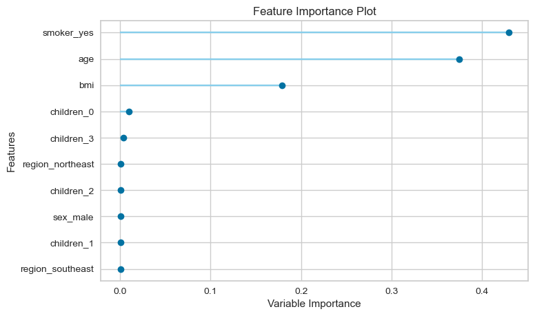

```
2020-11-19 14:32:27,326 - INFO     - Visual Rendered Successfully
2020-11-19 14:32:27,671 - INFO     - plot_model() succesfully completed......................................
```

```python
# importancia das variáveis de acordo com a floresta tunada

plot_model(floresta_tunada, plot = 'feature')
```